# Google Play Store Download Analysis by Raphael Trench

Again, lets see how plotting the same thing but with genres results in.

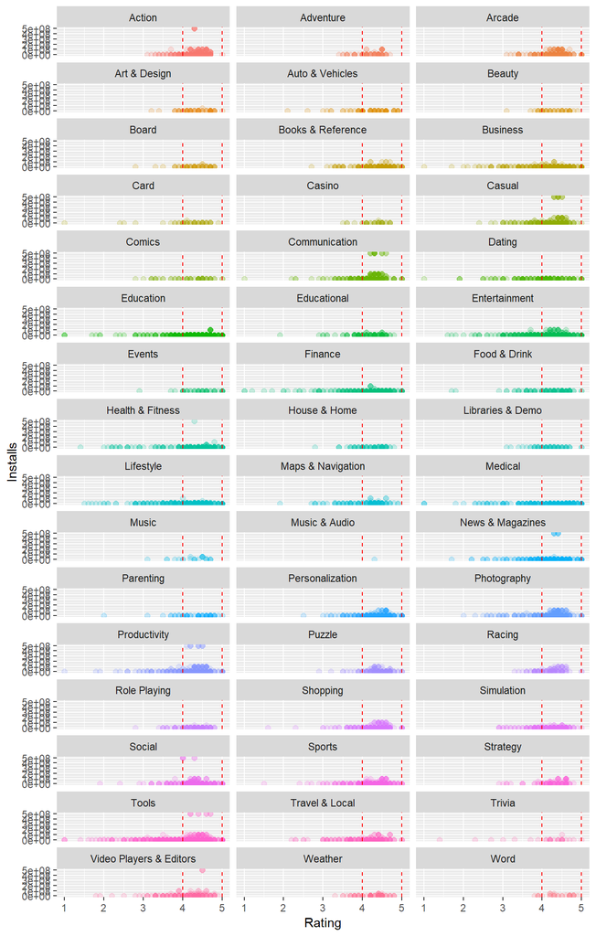

Interestingly, some of those genres have the same name of some of the most favoured categories, which further demonstrates that apps with these particular themes might be more prone to being successful.

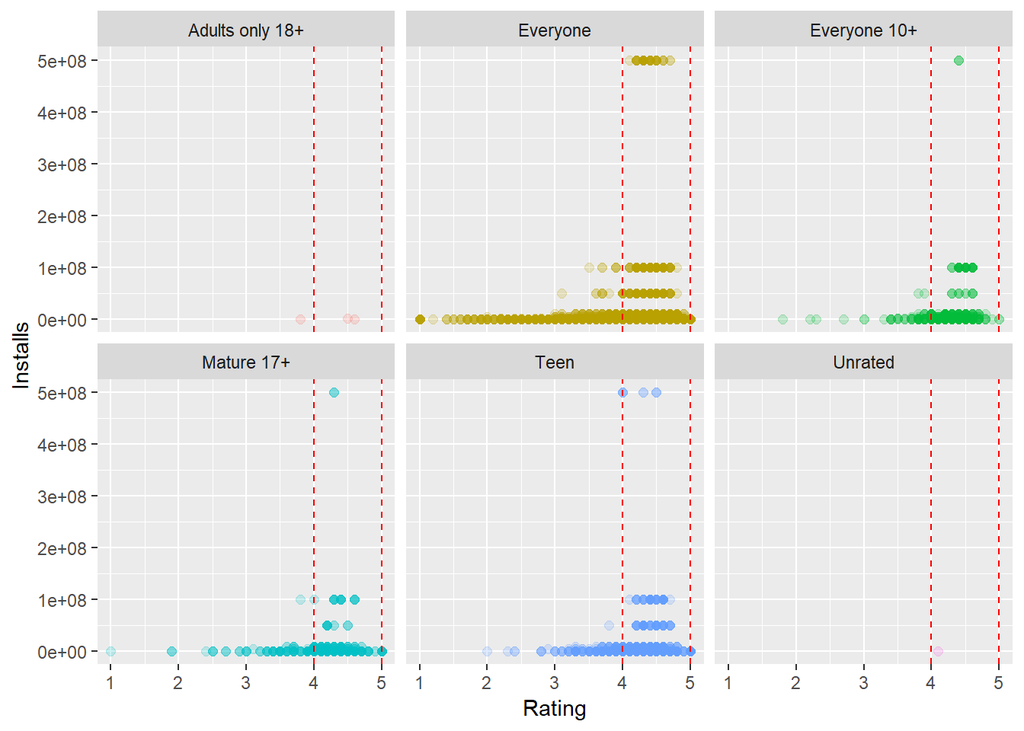

One can clearly see that there are more favoured apps that are rated for Everyone, followed by apps rated for teens.

Even if the Everyone content rating has more favoured apps though, it is also the category with most apps having ratings below 3, which could be considered poor ratings.

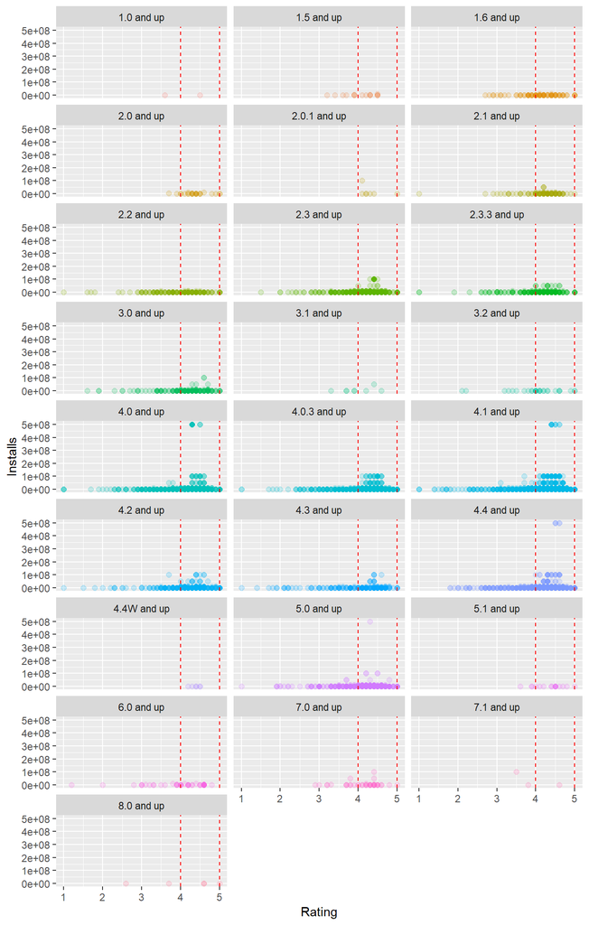

The plot above doesn’t give us any new information, since we already learned from the previous sections that the most downloaded apps have a minimum android version requirement between 4.0 and 5.0.

# Multivariate Analysis

### Talk about some of the relationships you observed in this part of the investigation. Were there features that strengthened each other in terms of looking at your feature(s) of interest?

Paid apps belonging to Game and Family categories are more succesful.

When analyzing apps by content rating, all types of content rating have the majority of their numerical ratings concentrated on values equal or greater than 3, save for apps rated for Everyone, which have their ratings ditributed between 1 and 5.

From all content rating categories, the Everyone category had the most favoured apps, followed by the Teen category.

### Were there any interesting or surprising interactions between features?

## Though there weren’t any surprising relationship between the features analyzed, it was very interesting to narrow down the pattern which the most successful apps followed.

# Final Plots and Summary

### Plot One

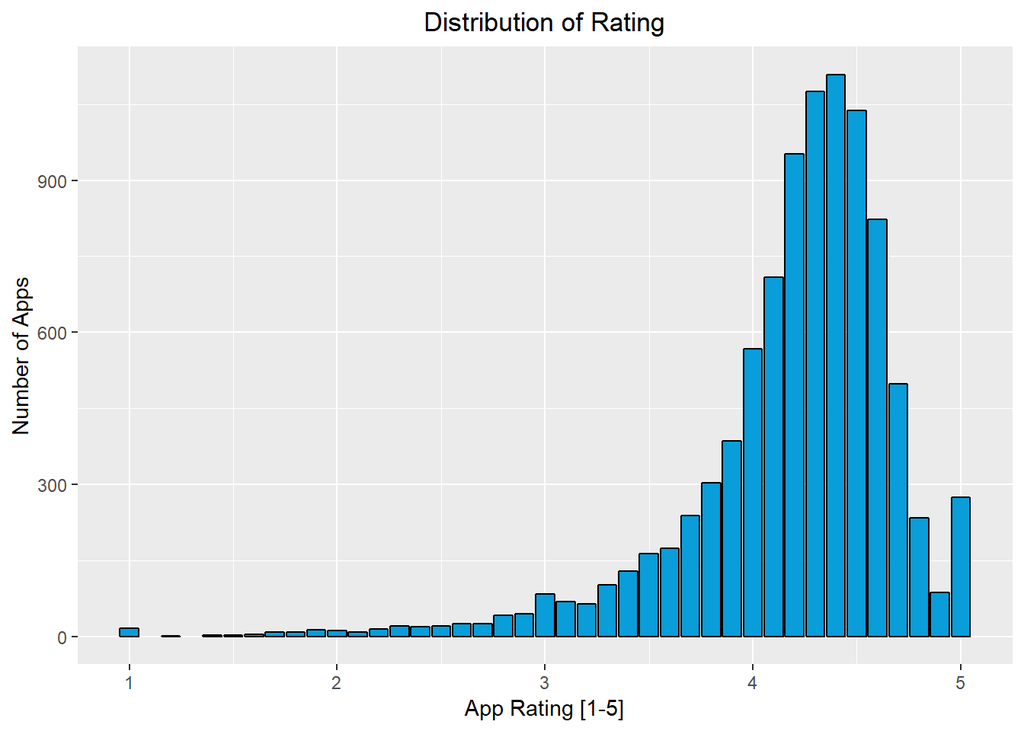

### Description One

The distribution is also centered at around 4.5.

### Plot Two

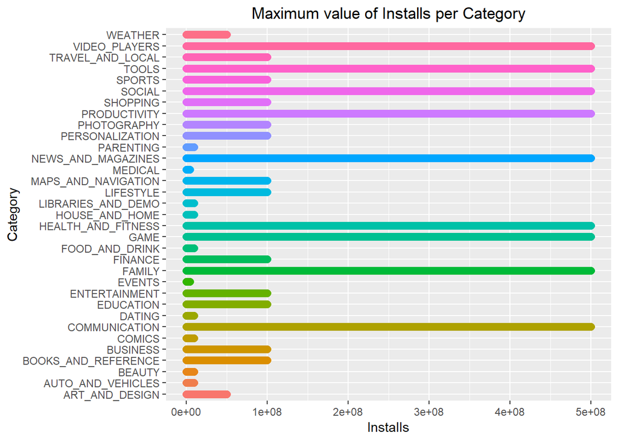

### Description Two

Apps from some category clearly reach a maximum number of installations overwhelmingly greater than others.

### Plot Three

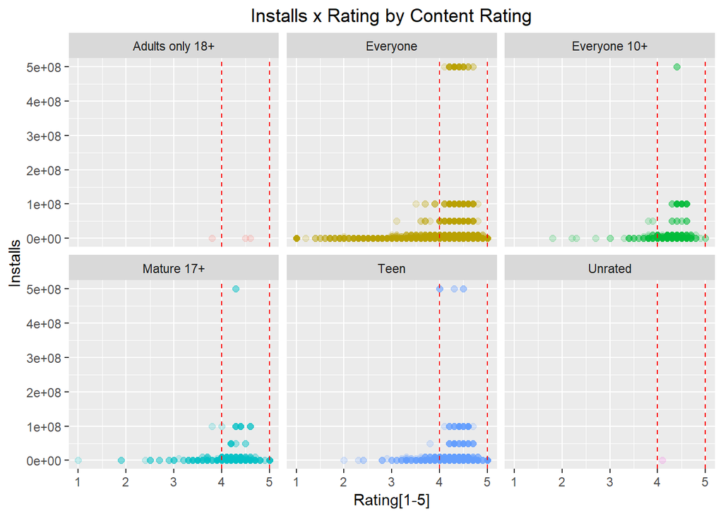

### Description Three

The plot shows for each type of content rating, the relationship between rating and the number of installs, bringing attention to ratings between 4 and 5.

Unrated and Adults only rated apps are less present in the dataset, and seem to have good ratings but not a high number of installationss

From the rest of the content rating categories, all of them have the majority of their app ratings equal or above 3, with the exception of the Everyone category.

Lastly, the Everyone and Teen rating categories have the most apps whith both a good rating and high number of installations.

# Reflection

The dataset that was analyzed had almost 11,000 observations with 13 different features.

I chose this dataset instead of the curated ones mainly because I had already worked with most of them during other Udacity courses, and I also wanted to explore something that is more interesting to me and was more ‘realistic’, meaning that came from the ‘real world’ and was messy.

It was good that I chose to not work with already clean data, as while I was working with this dataset, I learned alot about manipulating datasets using R.

A thing that troubled me initially was that the dataset is heavily categorical, and that includes the main feature of interest, Installs. That and the fact that most variables had a great number of unique categories, had me both putting a little bit more effort in creating plots that would best express the information and manipulating these variables. One of the biggest issues was that, since there are so many categories and a greate difference between the value of Installs, creating boxplots would result in pure visual pollution.

Overall I believe I was successful in trying to narrow down a pattern that the most successful apps follow, and even though obviously there are way more variables that aren’t taken into account in this dataset, such as simple things like app theme, quality, marketing, this is already good information to keep in mind should I ever choose to try my hand at developing an app.

Obviously, because of this lack of information, I dont believe it would be possible to create a good model that would be able to sucessfuly predict how many downloads an app will get in the appstore.

Because of how the dataset is structured, I reckon that I would be able to get more and better insights if I actually created a better dataset by datamining it myself, and analyzing it. This could be an interesting idea for future projects, and another one would be to just try analyzing more apps in general, not just from the google play store.